# Proyectos de R y Visualización con `{ggplot2}`

Módulo 6 - Organización del trabajo + visualización de datos + TP integrador

Pablo Tiscornia

[Estación R](https://estacion-r.com/)

2026-03-10

# Bienvenidos y bienvenidas

## Contacto con Estación R

#### [Slack](https://estacion-r.slack.com/)

#### [Web](https://estacion-r.com)

#### Correo

#### [Mastodon](https://botsin.space/@r_tips)

#### [X](https://twitter.com/estacion_erre)

#### [LinkedIn](https://www.linkedin.com/company/estacion-r/)

#### [Instagram](https://instagram.com/estacion_ere)

## ¿Qué vimos hasta ahora?

✅ La **EPH**: qué mide, cómo se estructura

✅ Conceptos básicos de **R**: valores, vectores, funciones, objetos

✅ **Tidyverse**: paquetes, importación, `select()`, `filter()`

✅ `mutate()`, `case_when()`, `summarise()`, `group_by()`

## Hoja de Ruta - Hoy

📁 **Proyectos de R** - Organizar la mesa de trabajo

📊 **ggplot2** - Visualización de datos

🎯 **TP integrador** - Consigna del trabajo final

🏁 ¡Último encuentro del curso!

# Proyectos de R

[figure not shown]

## El problema

- Hasta ahora importamos datos indicando la **ruta completa** del archivo:

```r
base_personas <- read_csv("/home/pablote/Documentos/datos/nombres-2015.csv")
```

## El problema

- Si compartimos el script a otra persona, **el código se rompe**
- Si cambiamos de computadora, **el código se rompe**
- Si cambiamos la base de lugar, **el código se rompe**

## La solución: Proyectos de RStudio

Un **proyecto de RStudio** define una carpeta como **directorio de trabajo**.

Esto significa que las rutas de archivos se vuelven **relativas** a esa carpeta.

> Ya no necesitamos rutas completas. Solo indicamos la ruta **dentro del proyecto**.

## Crear un proyecto - Paso a paso

**File → New Project → New Directory → New Project**

[figure not shown]

[figure not shown]

## Crear un proyecto - Resultado

[figure not shown]

## Antes vs. Después

**Antes** *(sin proyecto - ruta absoluta)*

```r
base_personas <- read_csv("/home/pablote/Documentos/datos/nombres-2015.csv")
```

**Después** *(con proyecto - ruta relativa)*

```r
base_personas <- read_csv("datos/nombres-2015.csv")
```

> Más corto, más portable, más reproducible.

## Estructura de carpetas recomendada

- 📂 **mi_proyecto/**

[figure not shown]

  - *mi_proyecto.Rproj*
  - 📂 **datos/**
    - ⛁ *eph_individual.csv*
  - 📂 **scripts/**
    - 📄 *01_procesamiento.R*
  - 📂 **outputs/**
    - 📊 *grafico_ingresos.png*
  - 📂 **docs/**
    - 📚 *informe.Rmd*

## Manos a la obra

1. **Crear un proyecto nuevo** en RStudio (o abrir el que veníamos usando)
2. Crear una carpeta `datos` y guardar ahí la base de la **EPH**
3. Crear un **script** nuevo y cargar los datos:

```r
library(tidyverse)
eph_ind <- read_csv("datos/eph_individual.csv")
```

# Visualización de datos

## ¿Por qué visualizar?

*“La visualización es el proceso de hacer visibles los contrastes, ritmos y eventos que los datos expresan, que no podemos percibir cuando vienen en forma de áridas listas de números.”*

- Interpretar y decodificar la información de forma visual
- Guiar hacia el hallazgo

# `{ggplot2}`

## ¿Qué es `{ggplot2}`?

- Una implementación del sistema **Grammar of Graphics** (Wilkinson, 2005).
- Un esquema pensado en **capas** (datos → plano → geometrías)
- Un paquete de funciones de aplicación **intuitiva**.

## ¿Por qué `{ggplot2}`?

- Tiene un marco de referencia (Grammar of Graphics)
- Flexible, con especificaciones a nivel de capas
- Sistema de `themes` para pulir la apariencia
- Decenas de extensiones para ampliar su potencia
- Comunidad activa y predispuesta a ayudar

## ¿A dónde vamos?

- Gráfico
- Código

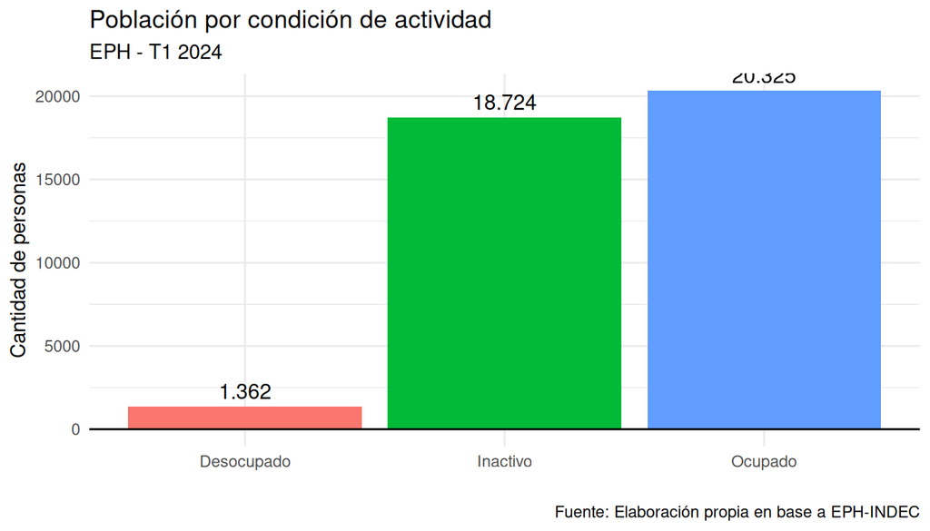

```r
eph_ind |>
  filter(ESTADO %in% c(1, 2, 3)) |>
  mutate(actividad = case_when(
    ESTADO == 1 ~ "Ocupado",
    ESTADO == 2 ~ "Desocupado",
    ESTADO == 3 ~ "Inactivo"
  )) |>
  summarise(cantidad = n(), .by = actividad) |>
  ggplot(aes(x = actividad, y = cantidad)) +
  geom_col(aes(fill = actividad)) +
  geom_text(aes(label = scales::number(cantidad, big.mark = ".")),
            vjust = -0.5, size = 4) +
  geom_hline(yintercept = 0) +
  labs(title = "Población por condición de actividad",
       subtitle = "EPH - T1 2024",
       x = "",
       y = "Cantidad de personas",
       caption = "Fuente: Elaboración propia en base a EPH-INDEC",
       fill = "Condición") +
  theme_minimal() +
  theme(legend.position = "none")
```

## Gráfico en clave de capas

3 capas son indispensables:

1. Los **datos** (`data =`): el dataframe de insumo
2. Las **aesthetics** (`aes()`): vínculo entre datos y propiedades visuales (ejes x, y)
3. Las **geometrías** (`geom_*()`): la forma con que se representan los datos

## Preparamos los datos

- **Pregunta:** ¿Cuántas personas hay por condición de actividad?

```r
df_actividad <- eph_ind |>
  filter(ESTADO %in% c(1, 2, 3)) |>
  mutate(actividad = case_when(
    ESTADO == 1 ~ "Ocupado",
    ESTADO == 2 ~ "Desocupado",
    ESTADO == 3 ~ "Inactivo"
  )) |>
  summarise(cantidad = n(), .by = actividad)
```

> Usamos todo lo aprendido en las clases anteriores: `filter()`, `mutate()`, `case_when()`, `summarise()`.

## Capa 1 y 2: datos + aesthetics

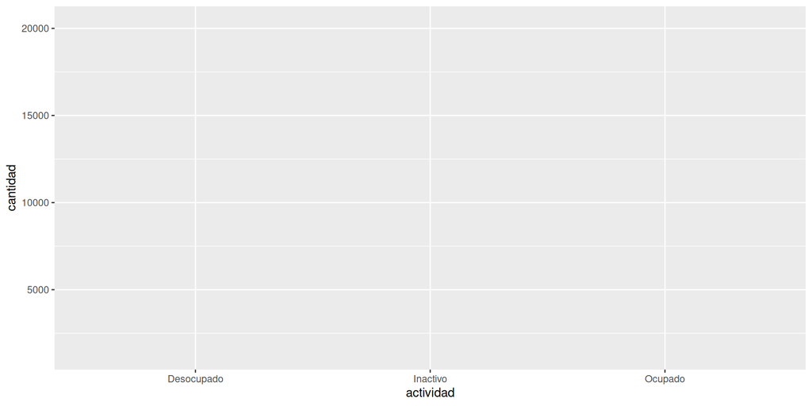

```r
ggplot(data = df_actividad,
       aes(x = actividad, y = cantidad))
```

## Capa 3: geometría

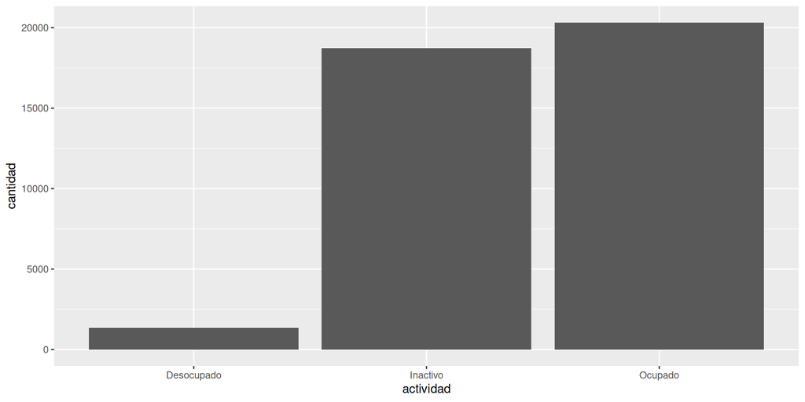

```r
ggplot(data = df_actividad,
       aes(x = actividad, y = cantidad)) +
  geom_col()
```

# Chapa y pintura

## Relleno con un color fijo

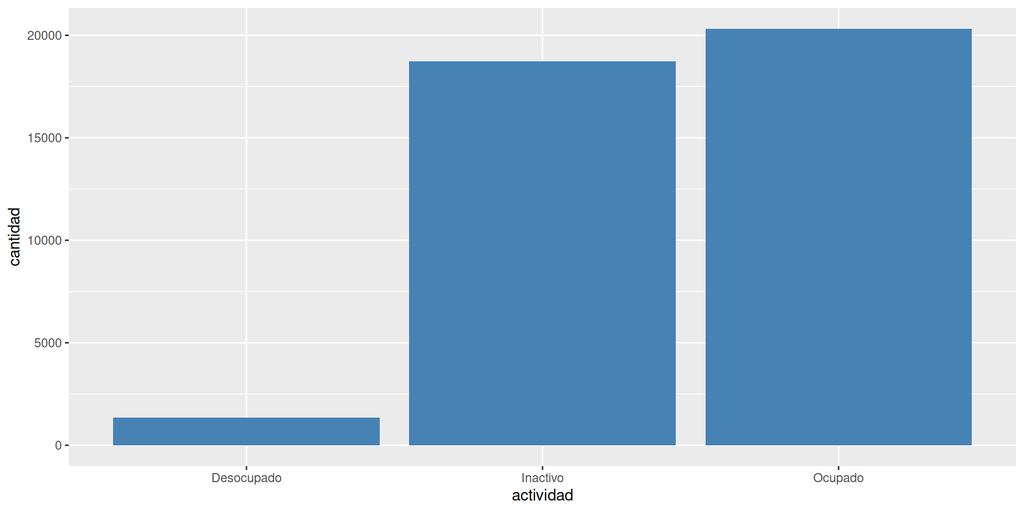

```r
ggplot(data = df_actividad,
       aes(x = actividad, y = cantidad)) +
  geom_col(fill = "steelblue")
```

## Relleno según una variable

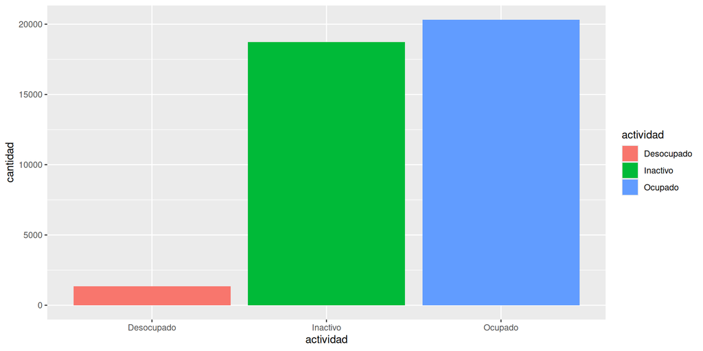

```r
ggplot(data = df_actividad,
       aes(x = actividad, y = cantidad)) +
  geom_col(aes(fill = actividad))
```

## Contorno

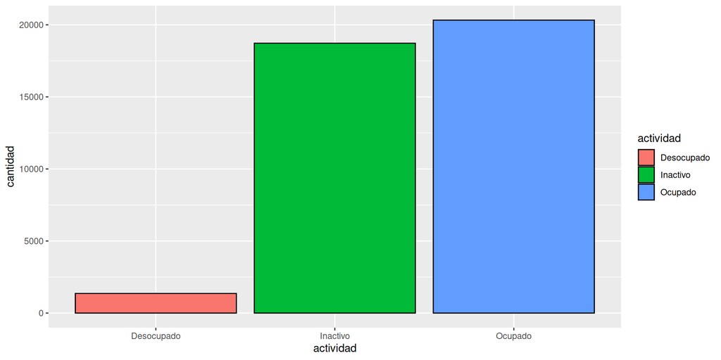

```r
ggplot(data = df_actividad,
       aes(x = actividad, y = cantidad)) +
  geom_col(aes(fill = actividad),
           color = "black")
```

## Referencias con `labs()`

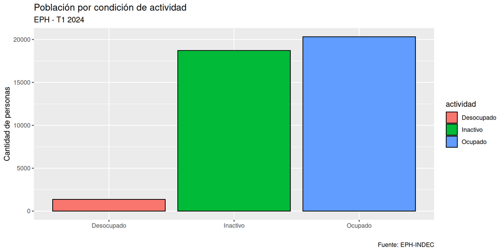

```r
ggplot(data = df_actividad,
       aes(x = actividad, y = cantidad)) +
  geom_col(aes(fill = actividad),
           color = "black") +
  labs(title = "Población por condición de actividad",
       subtitle = "EPH - T1 2024",
       x = "",
       y = "Cantidad de personas",
       caption = "Fuente: EPH-INDEC")
```

## Temas (`theme`)

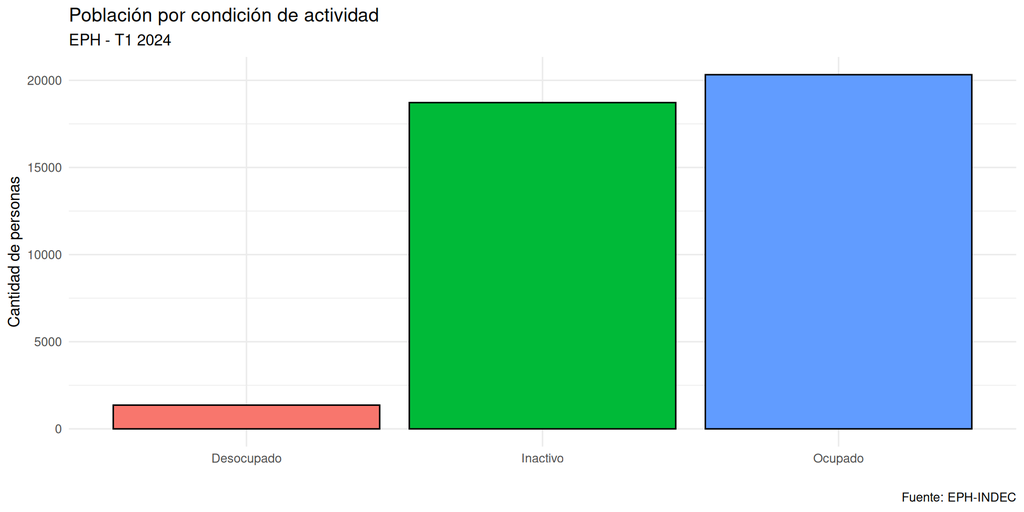

```r
ggplot(data = df_actividad,
       aes(x = actividad, y = cantidad)) +
  geom_col(aes(fill = actividad),
           color = "black") +
  labs(title = "Población por condición de actividad",
       subtitle = "EPH - T1 2024",
       x = "",
       y = "Cantidad de personas",
       caption = "Fuente: EPH-INDEC") +
  theme_minimal() +
  theme(legend.position = "none")
```

# Ejercitación

## Ejercitación: visualización con `{ggplot2}`

1. Calcular el **ingreso promedio** (`P21`) de la población **ocupada** (`ESTADO == 1`) con ingreso positivo (`P21 > 0`), **por sexo** (`CH04`). Recordar recodificar sexo con `case_when()`.
2. Con esa tabla, crear un gráfico de barras (`geom_col()`) con el **ingreso promedio en el eje y** y el **sexo en el eje x**.
3. Agregarle **relleno** por sexo, **título** y `theme_minimal()`.
4. **Desafío:** Hacer lo mismo pero agrupando por **sexo y región** (`REGION`). *Tip: usar `fill = factor(REGION)` dentro de `aes()`*.

## Resolución - Ejercicio 1 a 3

- Código
- Resultado

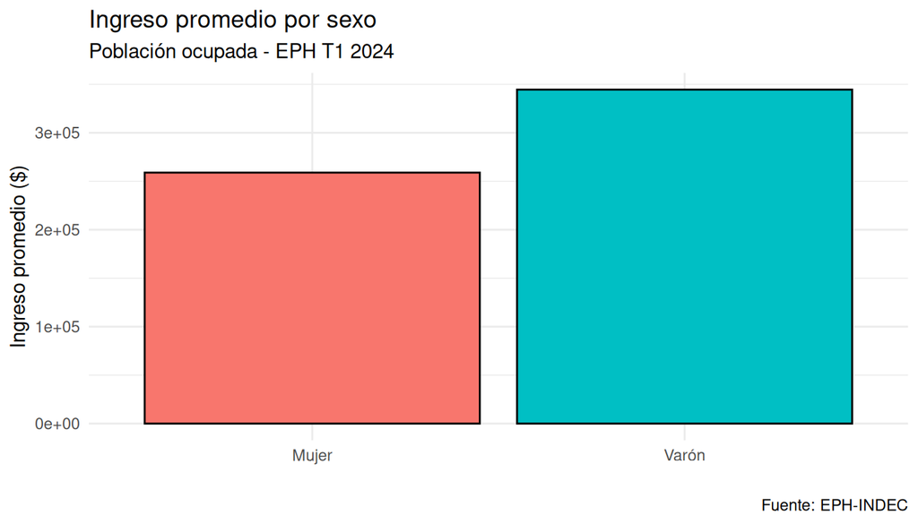

```r
df_ingreso_sexo <- eph_ind |>
  filter(ESTADO == 1, P21 > 0) |>
  mutate(sexo = case_when(CH04 == 1 ~ "Varón",
                          CH04 == 2 ~ "Mujer")) |>
  summarise(ingreso_promedio = mean(P21), .by = sexo)

ggplot(data = df_ingreso_sexo,
       aes(x = sexo, y = ingreso_promedio)) +
  geom_col(aes(fill = sexo), color = "black") +
  labs(title = "Ingreso promedio por sexo",
       subtitle = "Población ocupada - EPH T1 2024",
       x = "", y = "Ingreso promedio ($)",
       caption = "Fuente: EPH-INDEC") +
  theme_minimal() +
  theme(legend.position = "none")
```

# Trabajo Práctico Integrador

## Consigna del TP

**Tema:** Ejercicio de análisis con tema libre. Pueden usar la EPH u otra base de datos propia.

**Eje:** Plantear una pregunta sencilla sobre el tema elegido y responderla con datos.

**Contenido esperado:**

- **Importación** de datos
- **Procesamiento** con tidyverse (`filter`, `select`, `mutate`, `summarise`)
- **Visualización** con `ggplot2` (opcional, suma puntos)
- Breve **análisis** de los hallazgos

## Formato de entrega

📂 Enviar un **proyecto de RStudio** completo (carpeta con subcarpetas y archivos)

📄 Que contenga un **script de R** (.R) con el código del análisis

☁️ Subir a **Google Drive** (u otro servicio) y compartir el link

📧 Enviar a: **pablotiscornia@estacion-r.com**

📅 **Fecha de entrega:** Martes 8 de abril de 2026

## Tips para el TP

- No elegir una base muy compleja. La EPH está perfecta.
- Que el script **corra sin errores** de principio a fin.
- El **Slack** queda abierto para consultas.
- Se evalúa el **flujo de trabajo**, no la complejidad del análisis.

## Lo que logramos en el curso

✅ Conocer la **EPH** y sus datos

✅ Bases de **R**: objetos, funciones, vectores

✅ **Tidyverse** completo: importar, filtrar, seleccionar, transformar, resumir

✅ **Proyectos** de RStudio para organizar el trabajo

✅ **Visualización** de datos con ggplot2

## ¡Gracias!

### Fue un gusto acompañarlos en este recorrido

📧 pablotiscornia@estacion-r.com

💬 [Slack de Estación R](https://estacion-r.slack.com/)

> Recuerden: el Slack queda abierto para consultas sobre el TP. Fecha de entrega: **8 de abril de 2026**.